# Laboratorio 1

Author

Joshua Cervantes

Published

April 10, 2025

```python
# Se procede a importar los paquetes
import pandas as pd
import numpy as np
from cod.ejercicio import ejercicio_1 as ej1
import seaborn as sns
import matplotlib.pyplot as plt
```

# Ejercicio 1

## Notas escolares

```python
df_notas = pd.read_csv("./data/NotasEscolares.csv")
```

Se procede a llamar la clase que programamos

```python
notas_escolares_kmeans = ej1(df_notas.drop(["Estudiante"], axis = 1))
```

### 3 cluster

Hacemos el multistart con 3 clases

```python
notas_ms_3 = notas_escolares_kmeans.kmeans_multistart(3, 1000)
```

```python
notas_ms_3["mejor_inercia"]
```

```
8.159635931538446
```

La mejor inercia es inferior a 9.

```python
notas_ms_3["tau"]
```

```
84.3
```

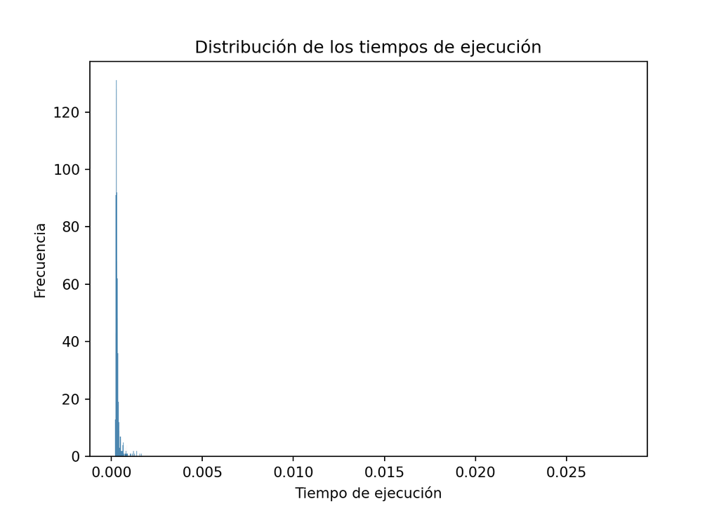

```python
notas_escolares_kmeans.plot_comportamiento_tiempos()
```

Los tiempos se encuentran realmente bajos siendo inferiores al segundo.

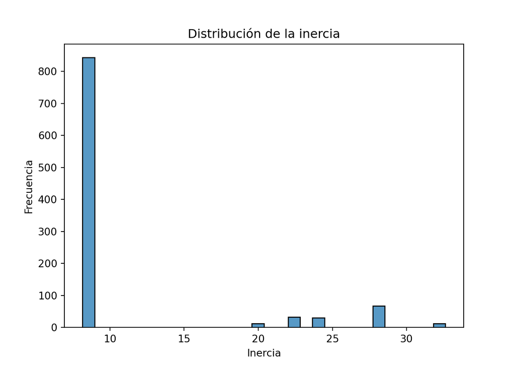

```python
notas_escolares_kmeans.plot_comportamiento_locales()
```

Se puede observar que la inercia en la mayoría de los casos se ubica poder debajo de 10. Aunque hay casos en los que la inercia queda realmente alta.

```python
notas_ms_3["iteraciones_promedio"]
```

```
2.965
```

Se puede obsevar que en esta tabla de datos cada multistart en promedio converge rápidamente.

### 4 cluster

Hacemos el multistart con 4 clases

```python
notas_ms_4 = notas_escolares_kmeans.kmeans_multistart(4, 1000)
```

```python
notas_ms_4["mejor_inercia"]
```

```
5.83348025046322
```

Se puede observar que la inercia obtenida en este caso es inferior al caso anterio como es de esperar dado que a mayor clases la inercia intraclase disminuye.

```python
notas_ms_4["tau"]
```

```
20.3
```

La tasa de atracción en este caso es mucho menor que en el caso anterior esto dado a que existe una mayor cantidad de combinaciones que se pueden hacer.

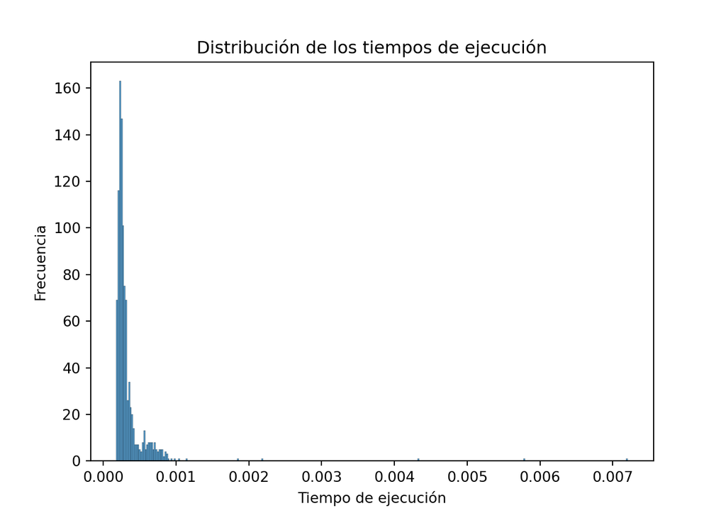

```python
notas_escolares_kmeans.plot_comportamiento_tiempos()
```

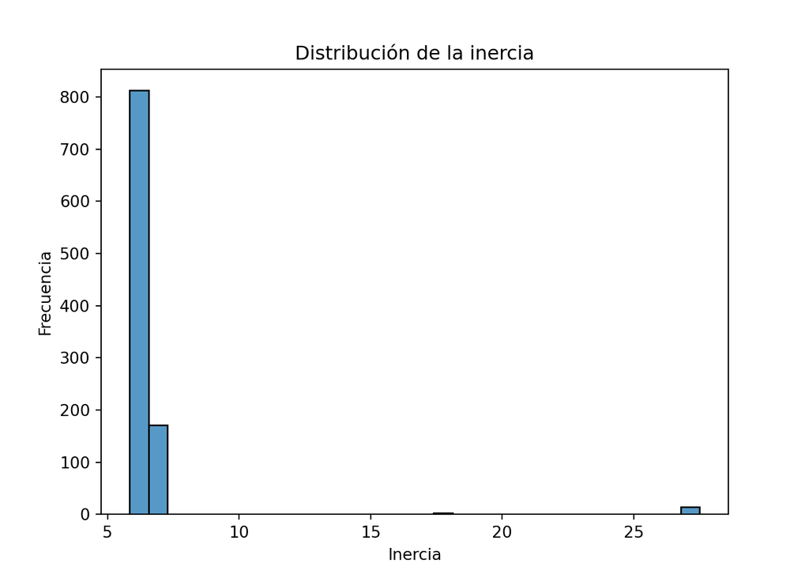

```python
notas_escolares_kmeans.plot_comportamiento_locales()
```

La inercia se comporta muy similar al caso anterior siendo inferior a 10, pero sí se nota que es mucho menor en general.

```python
notas_ms_4["iteraciones_promedio"]
```

```
2.816
```

Se disminuye el número de iteraciones.

## Peces de Amiard

```python
df_peces = pd.read_excel("./data/Amiard.xls", skiprows=1)
```

```python
peces_kmeans = ej1(df_peces.drop(["Pez"], axis = 1))
```

### 3 cluster

Hacemos el multistart con 3 clases

```python
peces_ms_3 = peces_kmeans.kmeans_multistart(3, 1000)
```

```python
peces_ms_3["mejor_inercia"]
```

```
176.8071046788838
```

```python
peces_ms_3["tau"]
```

```
14.7
```

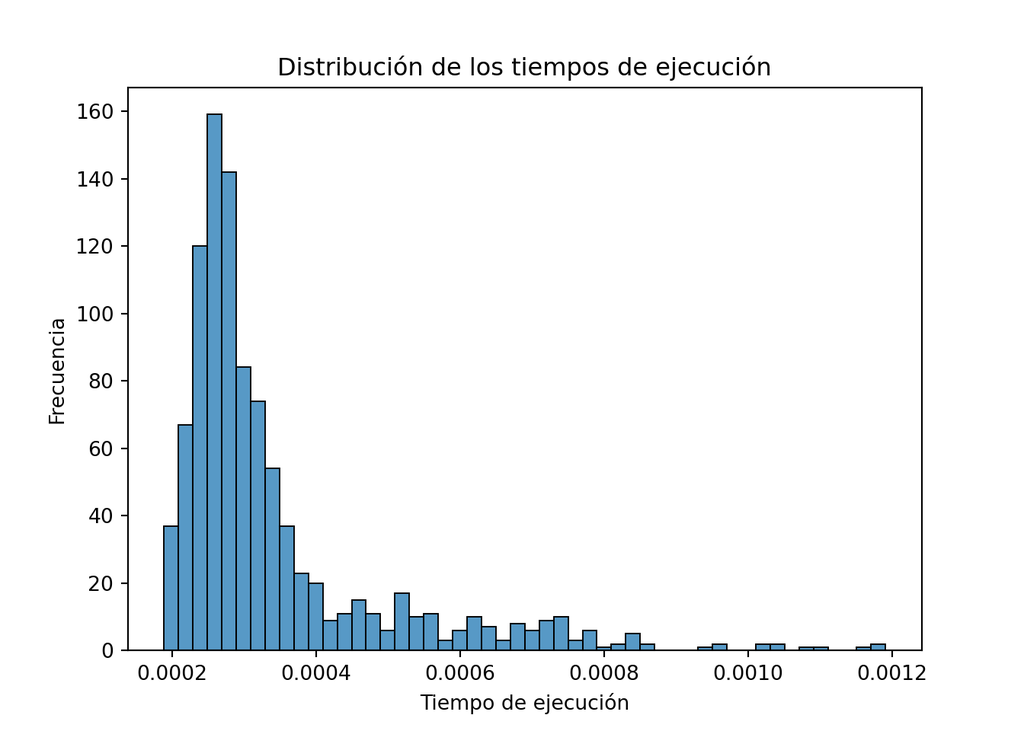

```python
peces_kmeans.plot_comportamiento_tiempos()
```

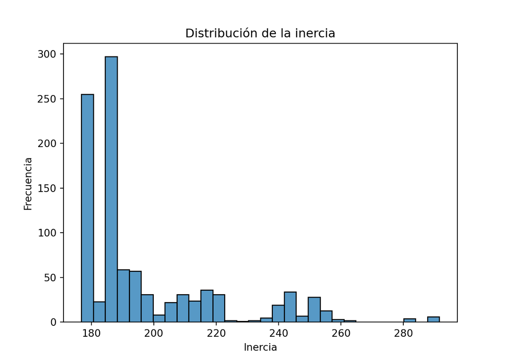

```python
peces_kmeans.plot_comportamiento_locales()
```

En este caso también se ubica una mayor variabilidad en la distirbución de las inercias. Se observa que existen claramente valores los cuales se repiten más alrededor de 180 y 190.

```python
peces_ms_3["iteraciones_promedio"]
```

```
3.697
```

Aquí en comparación con el ejercicio anterior existen más iteraciones en promedio.

### 4 cluster

Hacemos el multistart con 4 clases

```python
peces_ms_4 = peces_kmeans.kmeans_multistart(4, 1000)
```

```python
peces_ms_4["mejor_inercia"]
```

```
137.93760633243977
```

La inercia es mejor en este caso como es de esperarse.

```python
peces_ms_4["tau"]
```

```
8.799999999999999
```

La tasa de atracción en este caso es mucho menor dado que existe una mayor cantidad de combinaciones.

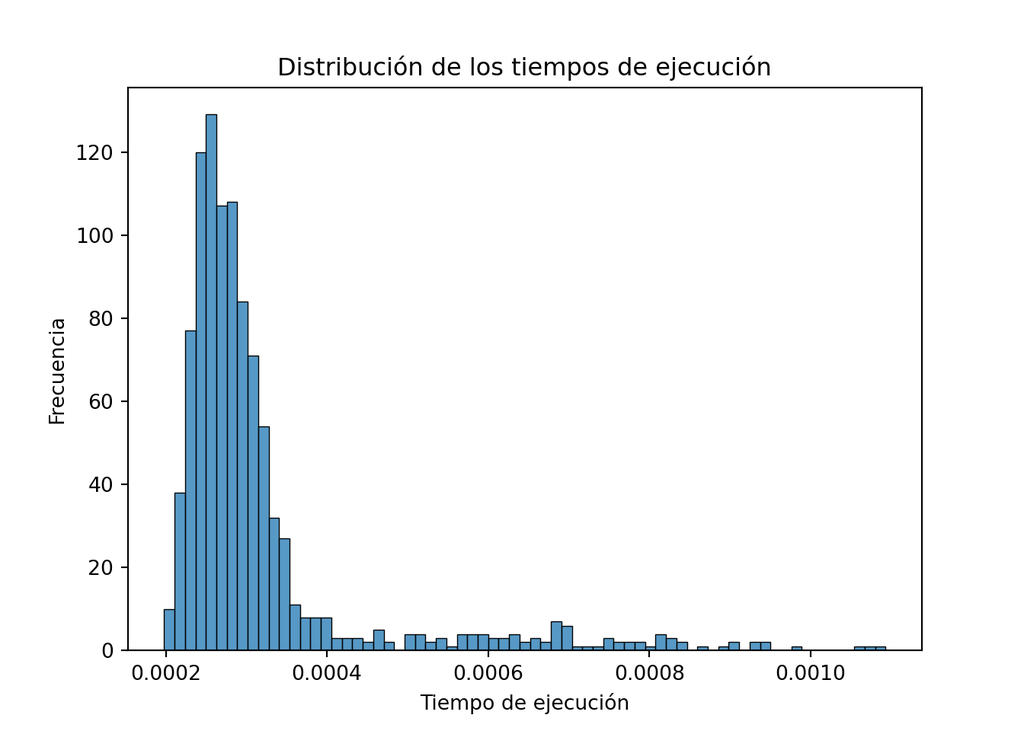

```python
peces_kmeans.plot_comportamiento_tiempos()
```

El tiempo de ejecución presenta una mayor cantidad de valores superiores a los mostrados en el ejemplo anterior en general.

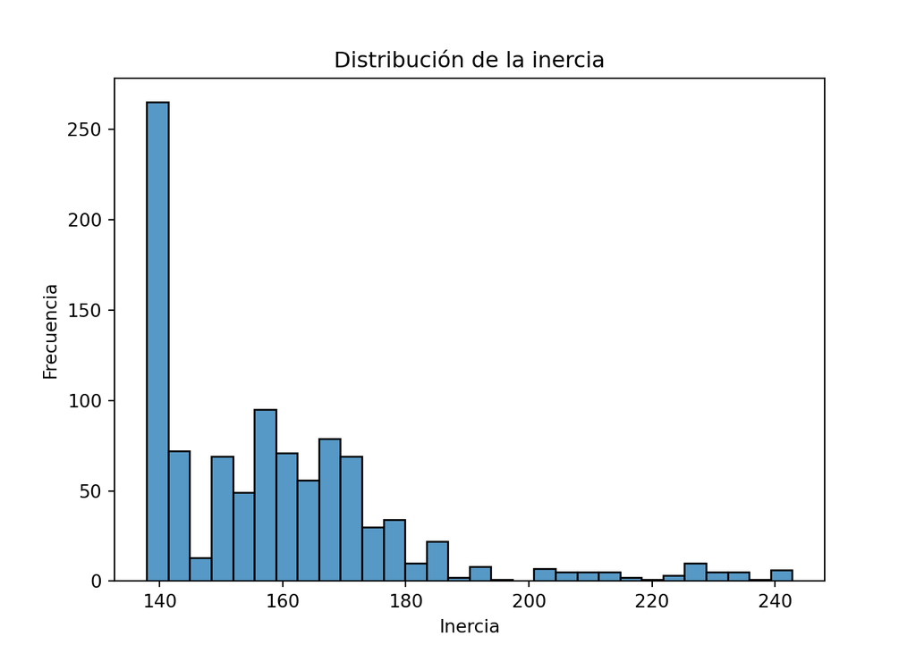

```python
peces_kmeans.plot_comportamiento_locales()
```

```python
peces_ms_4["iteraciones_promedio"]
```

```
3.941
```

## Iris

```python
from sklearn import datasets

iris = datasets.load_iris()
iris = pd.DataFrame(data= np.c_[iris['data'], iris['target']],columns= iris['feature_names'] + ['target'])
```

```python
iris_kmeans = ej1(iris.drop(["target"], axis = 1))
```

### 3 cluster

Hacemos el multistart con 3 clases

```python
iris_ms_3 = iris_kmeans.kmeans_multistart(3, 1000)
```

```python
iris_ms_3["mejor_inercia"]
```

```
139.82049635974982
```

```python
iris_ms_3["tau"]
```

```
10.299999999999999
```

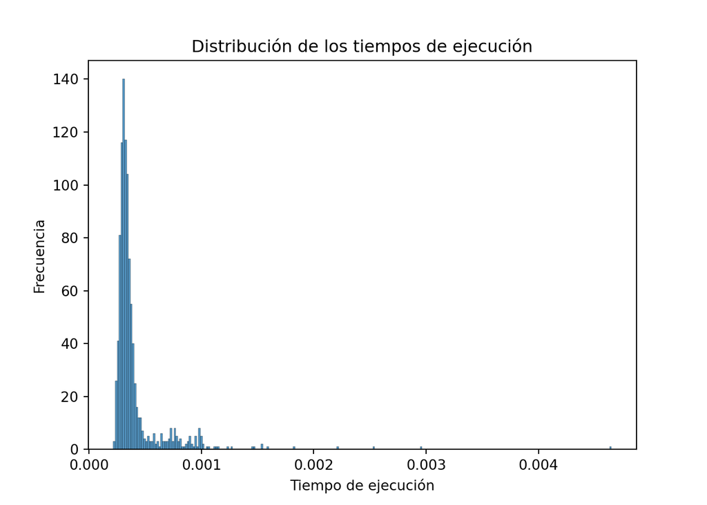

```python
iris_kmeans.plot_comportamiento_tiempos()
```

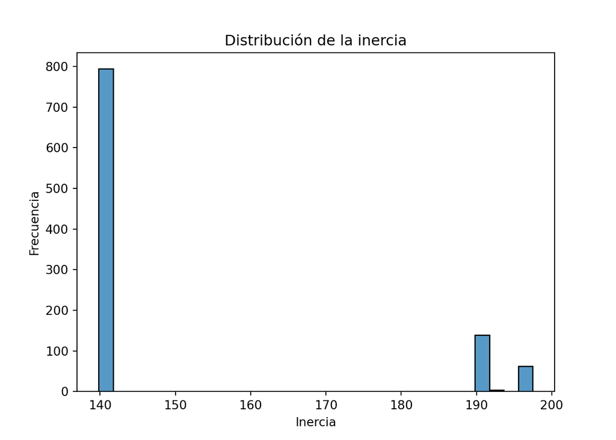

```python
iris_kmeans.plot_comportamiento_locales()
```

Se puede observar que la mayoría de los óptimo se ubican alrededor de 140.

```python
iris_ms_3["iteraciones_promedio"]
```

```
6.385
```

### 4 cluster

Hacemos el multistart con 4 clases

```python
iris_ms_4 = iris_kmeans.kmeans_multistart(4, 1000)
```

```python
iris_ms_4["mejor_inercia"]
```

```
114.09223843568273
```

La inercia mejora como es de esperarse.

```python
iris_ms_4["tau"]
```

```
0.6
```

Vemos que en este caso la tasa de atracción disminuye.

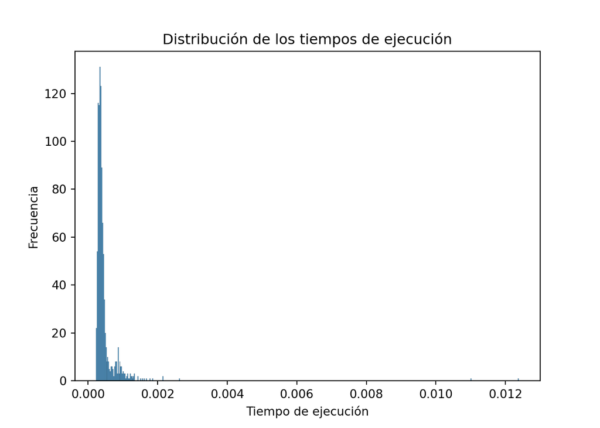

```python
iris_kmeans.plot_comportamiento_tiempos()
```

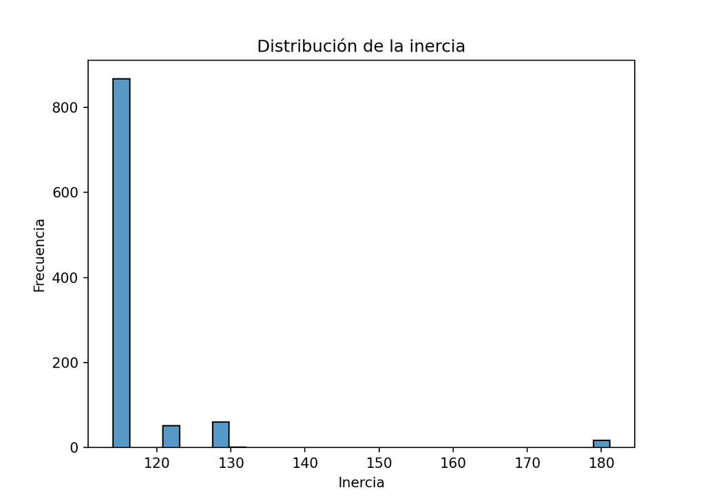

```python
iris_kmeans.plot_comportamiento_locales()
```

```python
iris_ms_4["iteraciones_promedio"]
```

```
8.583
```

En este caso el número de iteraciones aumenta.

# Ejercicio 2

## Mobile

```r
library(tidyverse)
source("./cod/ejercicio2.R")
df.mobile <- data.table::fread("./data/MOBILE.txt", sep = " ")
```

```r
objeto.mobile <- fn.ejercicio.2(datos = df.mobile, control = list(maxit = 150))

save(file = "./res/mobile.RData", objeto.mobile)
```

```r
load(file = "./res/mobile.RData")
```

Mejor 1-stress obtenido

```r
objeto.mobile$mejor.resultado$value
```

```
[1] 7.130981
```

Se presenta la tasa de atracción $\tau$

```r
objeto.mobile$tau*100
```

```
[1] 1
```

En este caso se observa que da 1% esto quiere decir que el mejor resultado se obtuvo una sola vez. Se intentó hacer estimar un error porcentual respecto al mejor resultado y el máximo de las diferencias de los valores, pero de esta manera igualmente se siguió obteniendo 1% como tasa de atracción.

Se presenta el $\overline{\sigma(\mathbf{X})}$

```r
objeto.mobile$promedio.stress
```

```
[1] 7.415259
```

Se reporta el tiempo de los multistart

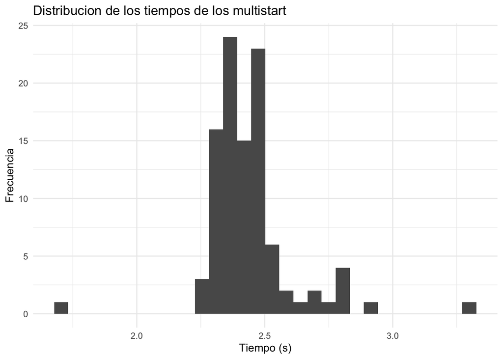

```r
ggplot2::ggplot(data.frame("tiempos" = objeto.mobile$tiempos), aes(x = tiempos)) +
        ggplot2::geom_histogram() +
        ggplot2::labs(title = "Distribucion de los tiempos de los multistart", x = "Tiempo (s)", y = "Frecuencia") +
        ggplot2::theme_minimal()
```

Se presenta el promedio de iteraciones de cada multistart

```r
objeto.mobile$promedio.iteraciones
```

```
[1] 150
```

En este caso se ubica en 150, pero esto se debe a que se había colocado como máximo 150 iteraciones, esto lo que puede indicar es que el modelo no está convergiendo por lo que se pueden requerir más iteraciones. Lamentablemente se ejecutó dos veces y en ambos casos se alcanzó como promedio el máximo de las iteracion 100 y 150.

Se presenta un histograma para mostrar los diferentes valores óptimos que se pueden tener.

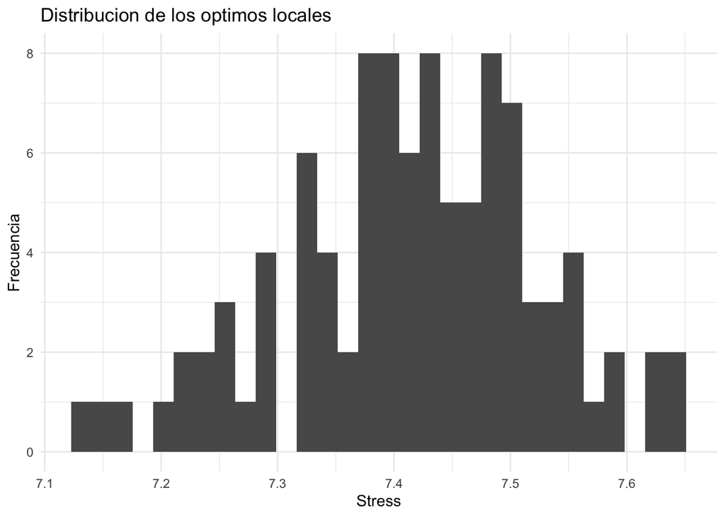

```r
ggplot2::ggplot(data.frame("stress" = objeto.mobile$stress), aes(x = stress)) +
        ggplot2::geom_histogram() +
        ggplot2::labs(title = "Distribucion de los optimos locales", x = "Stress", y = "Frecuencia") +
        ggplot2::theme_minimal()
```

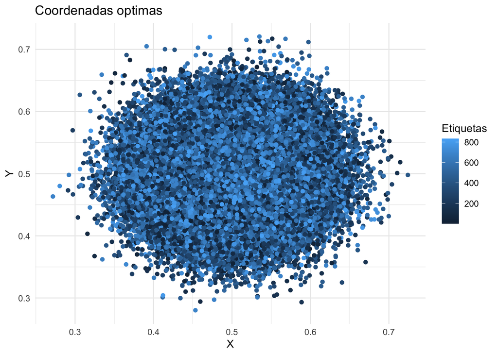

```r
ggplot2::ggplot(objeto.mobile$df.valores, aes(x = x, y = y, color = Etiquetas)) +
        ggplot2::geom_point() +
        ggplot2::labs(title = "Coordenadas optimas", x = "X", y = "Y") +
        ggplot2::theme_minimal()
```

En el gráfico no se ubica una gran diferencia entre los puntos, pero se puede observar que sí existe variación de acuerdo a los colores.

## Colas

```r
#Se procede a cargar la informacion de
df.colas <- data.table::fread("./data/COLAS.txt", sep = " ")
df.etiquetas <- data.table::fread("./data/colas.eti.txt", sep = " ")[2:11]
```

```r
colnames(df.colas) <- df.etiquetas$V1
df.colas$rows <- df.etiquetas$V1

df.colas <- df.colas %>%
    pivot_longer(cols = Diet_Pepsi:Diet_Rite, names_to = "V2", values_to = "V3")

colnames(df.colas) <- paste("V", 1:3, sep = "")
```

```r
objeto.colas <- fn.ejercicio.2(datos = df.colas)
save(file = "./res/colas.RData", objeto.colas)
```

```r
load(file = "./res/colas.RData")
```

Mejor 1-stress obtenido

```r
objeto.colas$mejor.resultado$value
```

```
[1] 234927.8
```

Se presenta la tasa de atracción $\tau$

```r
objeto.colas$tau*100
```

```
[1] 1
```

Se presenta el $\overline{\sigma(\mathbf{X})}$

```r
objeto.colas$promedio.stress
```

```
[1] 262313.1
```

El promedio es notoriamente superior al mejor valor obtenido de 1-stress.

Se reporta el tiempo de los multistart

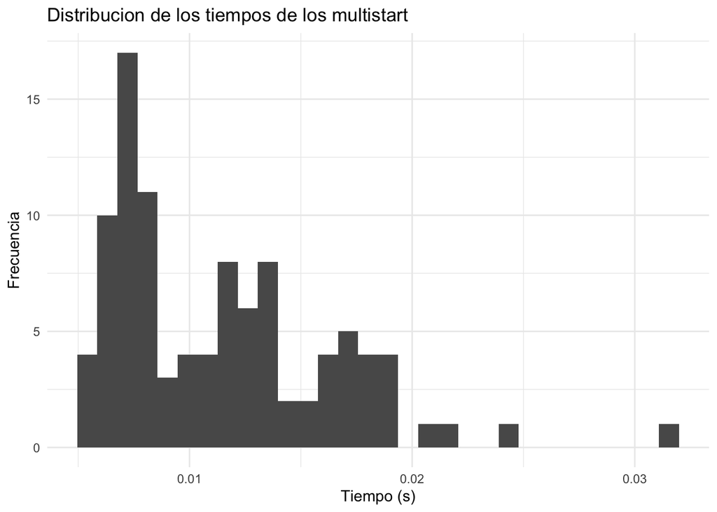

```r
objeto.colas$plot.time
```

Los tiempos en este caso sí son asimétricos. Al igual que los óptimos como se ve más adelante.

Se presenta el promedio de iteraciones de cada multistart

```r
objeto.colas$promedio.iteraciones
```

```
[1] 50.63
```

En este caso se puede observar que el promedio de iteraciones sí es inferior al máximo permitido por lo que el algoritmo sí parece converger.

Se presenta un histograma para mostrar los diferentes óptimos obtenidos

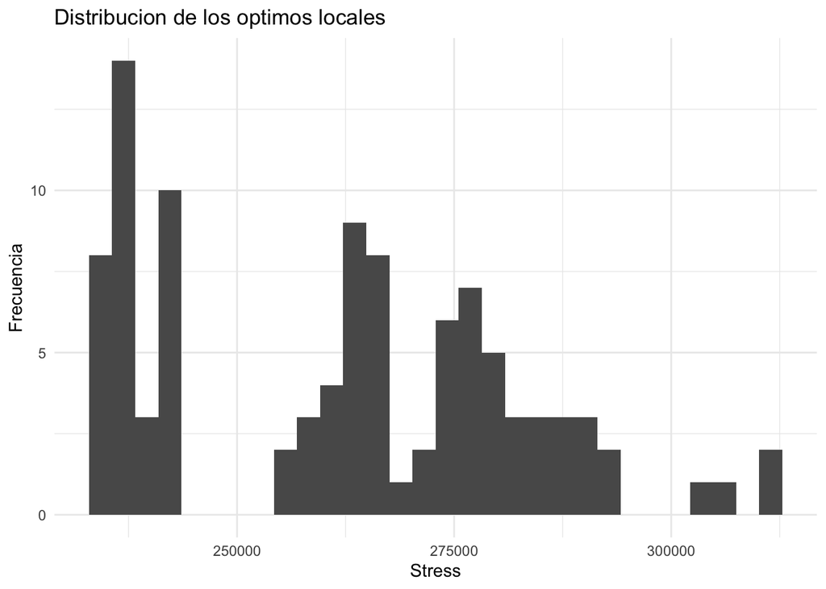

```r
objeto.colas$plot.optimos
```

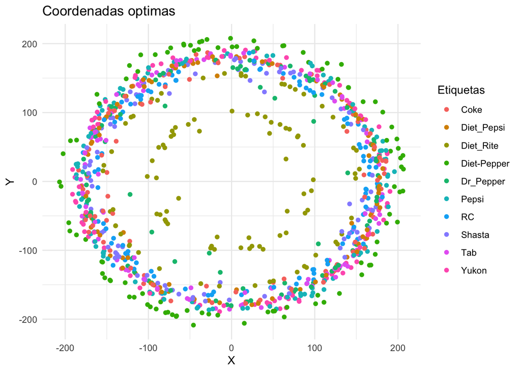

```r
objeto.colas$plot.coordendas.optimas
```

En este caso es interesante que se forma un comportamiento de rendondo, esto está relacionado con la norma que se está usando y se puede observar que una misma cola puede tener diferentes coordernadas mostrando las múltiples soluciones que existen.

## Ciudades Costa Rica

```r
df.ciudades <- openxlsx::read.xlsx("./data/Distancia_ciudades.xlsx")
df.ciudades <- df.ciudades %>%
    pivot_longer(cols = Alajuela:Puntarenas, names_to = "V2", values_to = "V3")


colnames(df.ciudades) <- paste("V", 1:3, sep = "")
```

```r
objeto.ciudades <- fn.ejercicio.2(datos = df.ciudades)
save(file = "./res/ciudades.RData", objeto.ciudades)
```

```r
load(file = "./res/ciudades.RData")
```

Mejor 1-stress obtenido

```r
objeto.ciudades$mejor.resultado$value
```

```
[1] 34361.04
```

Se presenta la tasa de atracción $\tau$

```r
objeto.ciudades$tau*100
```

```
[1] 1
```

En este caso se observa que da 1% esto quiere decir que el mejor resultado se obtuvo una sola vez con la mismca combinación de coordenadas.

Se presenta el $\overline{\sigma(\mathbf{X})}$

```r
objeto.ciudades$promedio.stress
```

```
[1] 77077.74
```

Se reporta el tiempo de los multistart

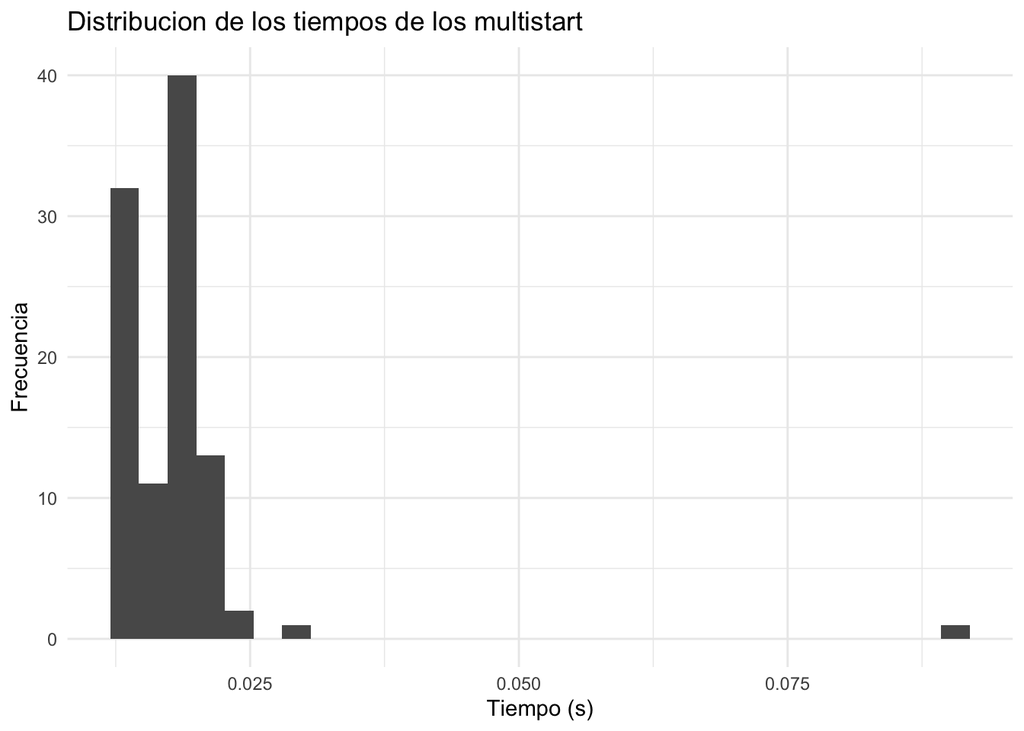

```r
objeto.ciudades$plot.time
```

Se presenta el promedio de iteraciones de cada multistart

```r
objeto.ciudades$promedio.iteraciones
```

```
[1] 44.53
```

En este caso se puede observar que el promedio de iteraciones sí es inferior al máximo permitido por lo que el algoritmo sí parece converger.

Se presenta un histograma para mostrar los diferentes valores óptimos que se pueden tener.

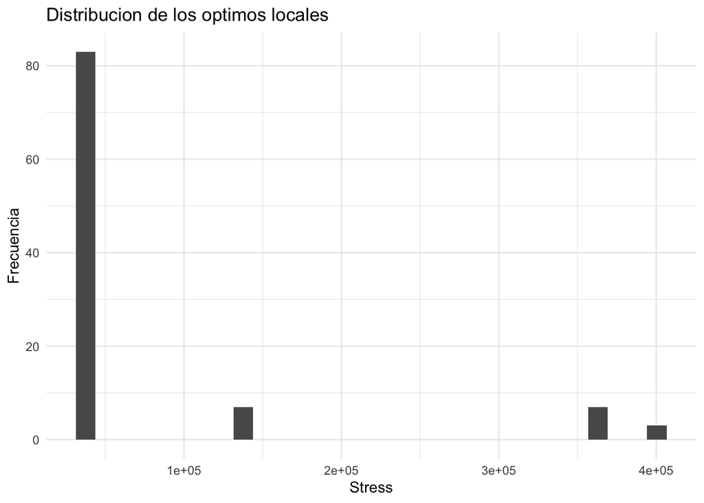

```r
objeto.ciudades$plot.optimos
```

Se puede observar que la mayoría de los óptimos tienen un valor similar.

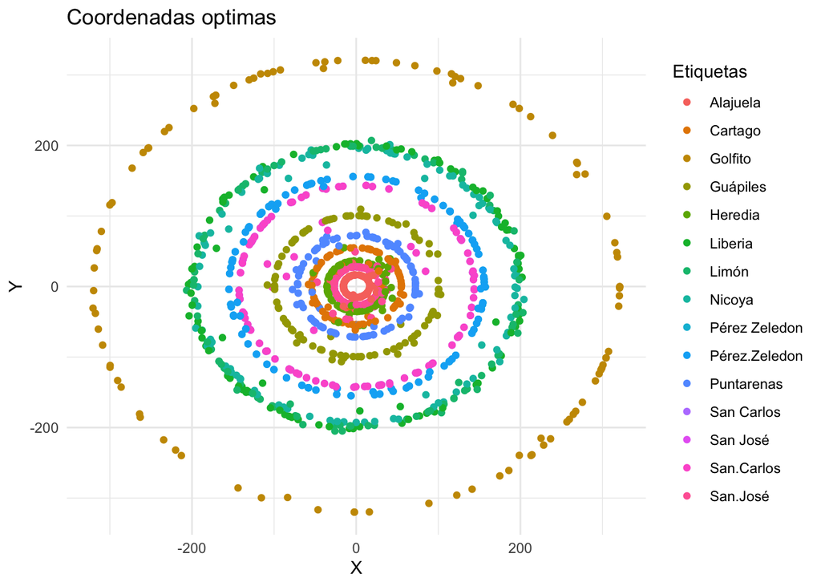

```r
objeto.ciudades$plot.coordendas.optimas
```

Se muestra un comportamiento similar al de las colas y se refuerza el hecho de que pueden existir múltiples soluciones para una misma ciudad.